# Clase 1

Paula Aguirre

2024-08-22

```r
library(tidyverse)
library(readxl)
library(lubridate)
library(sf)
library(ggmap)
library(tidygeocoder)
```

## 1. Procedemos a incorporar las librerías y seleccionar las bases de datos de los años 2022, 2023 y 2024. Las bases de 2022 y 2024 son en formato .csv, mientras que la base de 2023 es en formato .xlsx. Tambien cargo datasets de radios censales de las comunas para poder crear mapas

```r
suaci_2021 <-  read.csv("C:/Users/alejo/OneDrive/Escritorio/clinica_de_datos/desafio/datasets/sistema-unico-de-atencion-ciudadana-2021.csv",
                        sep = ";",
                        encoding = "latin1")

suaci_2022 <-  read.csv("C:/Users/alejo/OneDrive/Escritorio/clinica_de_datos/desafio/datasets/sistema-unico-de-atencion-ciudadana-2022.csv",
                        sep = ";",
                        encoding = "latin1")

suaci_2023 <- read_xlsx("C:/Users/alejo/OneDrive/Escritorio/clinica_de_datos/desafio/datasets/sistema-unico-de-atencion-ciudadana-2023.xlsx")

suaci_2024 <- read.csv("C:/Users/alejo/OneDrive/Escritorio/clinica_de_datos/desafio/datasets/sistema-unico-de-atencion-ciudadana-2024.csv",
                       sep = ",",
                       encoding = "UTF-8")

comunas_sf <- read_sf("C:/Users/alejo/OneDrive/Escritorio/clinica_de_datos/desafio/datasets/comunas.shp")

radio_censal <- read_sf("C:/Users/alejo/OneDrive/Escritorio/clinica_de_datos/desafio/datasets/informacion_censal_por_radio_2010_wgs84.shp")
```

exploramos brevemente los datasets

```r
dim(suaci_2022)
```

```
## [1] 104912     19
```

```r
dim(suaci_2023)
```

```
## [1] 831373     17
```

```r
dim(suaci_2024)
```

```
## [1] 492236     17
```

```r
names(suaci_2022)
```

```
##  [1] "contacto"                  "periodo"
##  [3] "categoria"                 "subcategoria"
##  [5] "prestacion"                "tipo_prestacion"
##  [7] "fecha_ingreso"             "hora_ingreso"
##  [9] "domicilio_comuna"          "domicilio_barrio"
## [11] "domicilio_calle"           "domicilio_altura"
## [13] "domicilio_esquina_proxima" "lat"
## [15] "lon"                       "canal"
## [17] "genero"                    "estado_del_contacto"
## [19] "fecha_cierre_contacto"
```

```r
names(suaci_2023)
```

```
##  [1] "NRO_SOLICITUD"   "PERIODO"         "CATEGORIA"       "PRESTACION"
##  [5] "TIPO"            "FECHA_INGRESO"   "HORA_INGRESO"    "COMUNA"
##  [9] "BARRIO"          "CALLE"           "ALTURA"          "ESQUINA_PROXIMA"
## [13] "CANAL"           "X"               "Y"               "GENERO"
## [17] "ESTADO_GENERAL"
```

```r
names(suaci_2024)
```

```
##  [1] "nro_solicitud"   "periodo"         "categoria"       "prestacion"
##  [5] "tipo"            "fecha_ingreso"   "hora_ingreso"    "comuna"
##  [9] "barrio"          "calle"           "altura"          "esquina_proxima"
## [13] "canal"           "long"            "lat"             "genero"
## [17] "estado_general"
```

```r
head(suaci_2022)
```

```
##      contacto periodo              categoria             subcategoria
## 1 00000146/22  202201     BARRIOS EMERGENTES SERVICIO DE ELECTRICIDAD
## 2 00000155/22  202201 LIMPIEZA Y RECOLECCIÓN  LIMPIEZA DE VÍA PÚBLICA
## 3 00001990/22  202201     BARRIOS EMERGENTES          DESOBSTRUCCIÓN
## 4 00001541/22  202201              SEGURIDAD                    OTROS
## 5 00002069/22  202201     BARRIOS EMERGENTES          DESOBSTRUCCIÓN
## 6 00000812/22  202201     BARRIOS EMERGENTES SERVICIO DE ELECTRICIDAD
##                 prestacion tipo_prestacion fecha_ingreso   hora_ingreso
## 1 Servicio de electricidad       Solicitud    2022-01-01 05:54:41 p. m.
## 2     Lavado de contenedor       Solicitud    2022-01-01 06:00:50 p. m.
## 3  Desobstrucción (Vactor)       Solicitud    2022-01-04 12:15:01 a. m.
## 4 Mayor presencia policial         Reporte    2022-01-03 03:33:11 p. m.
## 5  Desobstrucción (Vactor)       Solicitud    2022-01-04 01:00:44 a. m.
## 6 Servicio de electricidad       Solicitud    2022-01-02 11:21:27 p. m.
##   domicilio_comuna domicilio_barrio domicilio_calle domicilio_altura
```

[output cut: 20 more lines]

```r
head(suaci_2023)
```

```
## # A tibble: 6 × 17
##   NRO_SOLICITUD PERIODO CATEGORIA    PRESTACION TIPO  FECHA_INGRESO HORA_INGRESO
##   <chr>         <chr>   <chr>        <chr>      <chr> <chr>         <chr>
## 1 00088947/23   202302  ARBOLADO     Poda de á… Soli… 2023-02-13    12:02:44 PM
## 2 00011866/23   202301  ALUMBRADO    Reparació… Soli… 2023-01-06    10:01:08 PM
## 3 00013332/23   202301  DENUNCIA VI… Vehículo … Denu… 2023-01-08    04:01:15 PM
## 4 00014169/23   202301  HIGIENE      Retiro de… Serv… 2023-01-09    10:01:15 AM
## 5 00005174/23   202301  HIGIENE      Retiro de… Serv… 2023-01-04    08:01:23 AM
## 6 00005253/23   202301  AGC FISCALI… Irregular… Denu… 2023-01-04    09:01:26 AM
## # ℹ 10 more variables: COMUNA <chr>, BARRIO <chr>, CALLE <chr>, ALTURA <dbl>,
## #   ESQUINA_PROXIMA <chr>, CANAL <chr>, X <dbl>, Y <dbl>, GENERO <chr>,
## #   ESTADO_GENERAL <chr>
```

```r
head(suaci_2024)
```

```
##   nro_solicitud periodo               categoria
## 1   00006831/24  202401                 HIGIENE
## 2   00006841/24  202401                 HIGIENE
## 3   00008307/24  202401                 HIGIENE
## 4   00002431/24  202401 ACCESO A LA INFORMACIÓN
## 5   00002445/24  202401   DEFENSA AL CONSUMIDOR
## 6   00003233/24  202401                   SALUD
##                                                             prestacion
## 1                                   Retiro de escombros/restos de obra
## 2                   Retiro de restos de poda o jardinería domiciliaria
## 3                 Desratizar, desinsectar y desinfectar en vía pública
## 4                                      Acceso a la información pública
## 5                        Incumplimientos a los derechos del consumidor
## 6 Inconvenientes con la atención en Centro de Salud u Hospital Público
##        tipo fecha_ingreso hora_ingreso comuna           barrio        calle
```

[output cut: 20 more lines]

```r
summary(suaci_2022)
```

```
##    contacto            periodo        categoria         subcategoria
##  Length:104912      Min.   :202201   Length:104912      Length:104912
##  Class :character   1st Qu.:202201   Class :character   Class :character
##  Mode  :character   Median :202202   Mode  :character   Mode  :character
##                     Mean   :202202
##                     3rd Qu.:202202
##                     Max.   :202203
##
##   prestacion        tipo_prestacion    fecha_ingreso      hora_ingreso
##  Length:104912      Length:104912      Length:104912      Length:104912
##  Class :character   Class :character   Class :character   Class :character
##  Mode  :character   Mode  :character   Mode  :character   Mode  :character
##
##
##
##
##  domicilio_comuna   domicilio_barrio   domicilio_calle    domicilio_altura
##  Length:104912      Length:104912      Length:104912      Min.   :   -1
##  Class :character   Class :character   Class :character   1st Qu.: 1096
##  Mode  :character   Mode  :character   Mode  :character   Median : 2310
##                                                           Mean   : 2521
##                                                           3rd Qu.: 3611
##                                                           Max.   :16310
##                                                           NA's   :15091
##  domicilio_esquina_proxima     lat                lon
##  Length:104912             Length:104912      Length:104912
##  Class :character          Class :character   Class :character
##  Mode  :character          Mode  :character   Mode  :character
##
##
##
##
##     canal              genero          estado_del_contacto
##  Length:104912      Length:104912      Length:104912
##  Class :character   Class :character   Class :character
##  Mode  :character   Mode  :character   Mode  :character
##
##
##
##
##  fecha_cierre_contacto
##  Length:104912
##  Class :character
##  Mode  :character
##
##
##
##
```

```r
summary(suaci_2023)
```

```
##  NRO_SOLICITUD        PERIODO           CATEGORIA          PRESTACION
##  Length:831373      Length:831373      Length:831373      Length:831373
##  Class :character   Class :character   Class :character   Class :character
##  Mode  :character   Mode  :character   Mode  :character   Mode  :character
##
##
##
##
##      TIPO           FECHA_INGRESO      HORA_INGRESO          COMUNA
##  Length:831373      Length:831373      Length:831373      Length:831373
##  Class :character   Class :character   Class :character   Class :character
##  Mode  :character   Mode  :character   Mode  :character   Mode  :character
##
##
##
##
##     BARRIO             CALLE               ALTURA      ESQUINA_PROXIMA
##  Length:831373      Length:831373      Min.   :   -1   Length:831373
##  Class :character   Class :character   1st Qu.: 1068   Class :character
##  Mode  :character   Mode  :character   Median : 2226   Mode  :character
##                                        Mean   : 2475
##                                        3rd Qu.: 3551
##                                        Max.   :17122
##                                        NA's   :89282
##     CANAL                 X                Y             GENERO
##  Length:831373      Min.   : 93792   Min.   : 91732   Length:831373
##  Class :character   1st Qu.: 97927   1st Qu.:100154   Class :character
##  Mode  :character   Median :100606   Median :102448   Mode  :character
##                     Mean   :100902   Mean   :102522
##                     3rd Qu.:103704   3rd Qu.:104957
##                     Max.   :111035   Max.   :110905
##                     NA's   :40693    NA's   :40693
##  ESTADO_GENERAL
##  Length:831373
##  Class :character
##  Mode  :character
##
##
##
##
```

```r
summary(suaci_2024)
```

```
##  nro_solicitud         periodo        categoria          prestacion
##  Length:492236      Min.   :202401   Length:492236      Length:492236
##  Class :character   1st Qu.:202402   Class :character   Class :character
##  Mode  :character   Median :202404   Mode  :character   Mode  :character
##                     Mean   :202404
##                     3rd Qu.:202406
##                     Max.   :202408
##
##      tipo           fecha_ingreso      hora_ingreso           comuna
##  Length:492236      Length:492236      Length:492236      Min.   : 1.00
##  Class :character   Class :character   Class :character   1st Qu.: 6.00
##  Mode  :character   Mode  :character   Mode  :character   Median :10.00
##                                                           Mean   : 9.05
##                                                           3rd Qu.:12.00
##                                                           Max.   :15.00
##                                                           NA's   :40832
##     barrio             calle               altura      esquina_proxima
##  Length:492236      Length:492236      Min.   :    1   Length:492236
##  Class :character   Class :character   1st Qu.: 1084   Class :character
##  Mode  :character   Mode  :character   Median : 2252   Mode  :character
##                                        Mean   : 2495
##                                        3rd Qu.: 3572
##                                        Max.   :16832
##                                        NA's   :80804
##     canal                long             lat            genero
##  Length:492236      Min.   : 93784   Min.   : 92351   Length:492236
##  Class :character   1st Qu.: 97809   1st Qu.:100298   Class :character
##  Mode  :character   Median :100482   Median :102556   Mode  :character
##                     Mean   :100828   Mean   :102612
##                     3rd Qu.:103675   3rd Qu.:105006
##                     Max.   :111063   Max.   :110905
##                     NA's   :40792    NA's   :40792
##  estado_general
##  Length:492236
##  Class :character
##  Mode  :character
##
##
##
##
```

## 2. Procedemos a analizar cada base de datos.

En el año 2022 se registran 104.912 registros, con 19 columnas.

En el año 2023 se registran 831.373 registros, con 17 columnas.

En el año 2024 se registran 492.236 registros, con 17 columnas.

## 3. Procedemos a renombrar las variables y cantidad de columnas tomando de referencia el primer año “2022”, para generar uniformidad en la exposición de información.

```r
suaci_2022_clean <- suaci_2022 %>%
  select(-subcategoria,-fecha_cierre_contacto)

suaci_2021_clean <- suaci_2021 %>%
  select(-subcategoria,-fecha_cierre_contacto)

suaci_2021_clean <- suaci_2021_clean %>%
  rename(domicilio_calle = domiclio_calle)

suaci_2023_rename <- suaci_2023 %>%
  rename(contacto = NRO_SOLICITUD,
         periodo = PERIODO,
         categoria = CATEGORIA,
         prestacion =PRESTACION,
         tipo_prestacion =TIPO,
         fecha_ingreso = FECHA_INGRESO,
         hora_ingreso = HORA_INGRESO,
         domicilio_comuna = COMUNA,
         domicilio_barrio = BARRIO,
         domicilio_calle = CALLE,
         domicilio_altura = ALTURA,
         domicilio_esquina_proxima = ESQUINA_PROXIMA,
         lat = X,
         lon = Y,
         genero = GENERO,
         estado_del_contacto = ESTADO_GENERAL,
         canal = CANAL)

suaci_2024_rename <- suaci_2024 %>%
  rename(contacto = nro_solicitud,
         periodo = periodo,
         categoria = categoria,
         prestacion =prestacion,
         tipo_prestacion =tipo,
         fecha_ingreso = fecha_ingreso,
         hora_ingreso = hora_ingreso,
         domicilio_comuna = comuna,
         domicilio_barrio = barrio,
         domicilio_calle = calle,
         domicilio_altura = altura,
         domicilio_esquina_proxima = esquina_proxima,
         lat = lat,
         lon = long,
         genero = genero,
         estado_del_contacto = estado_general,
         canal = canal)

comunas_sf <- comunas_sf %>%
  rename(domicilio_comuna = comuna)

radio_censal <- radio_censal %>%
  rename(domicilio_comuna = COMUNA)

radio_censal <- radio_censal %>%
  st_drop_geometry()%>%
  group_by(domicilio_comuna) %>%
  summarise(total = sum(TOTAL_POB))

suaci_2021_clean <- suaci_2021_clean[,c(1,2,3,4,5,6,7,8,9,10,11,12,15,14,13,16,17)]
```

##4 unimos los datasets para poder trabajar mejor los datos

```r
suaci_21_24 <- rbind(suaci_2024_rename,suaci_2023_rename)
suaci_21_24 <- rbind(suaci_21_24, suaci_2022_clean)
suaci_21_24 <- rbind(suaci_21_24, suaci_2021_clean)
```

## normalizamos los nombres de las comunas y otras variables relevantes

```r
#primero unificamos los nombres de las comunas para que sea posible agrupar
suaci_21_24$domicilio_comuna[suaci_21_24$domicilio_comuna == '1'] <- 'COMUNA 1'
suaci_21_24$domicilio_comuna[suaci_21_24$domicilio_comuna == '2'] <- 'COMUNA 2'
suaci_21_24$domicilio_comuna[suaci_21_24$domicilio_comuna == '3'] <- 'COMUNA 3'
suaci_21_24$domicilio_comuna[suaci_21_24$domicilio_comuna == '4'] <- 'COMUNA 4'
suaci_21_24$domicilio_comuna[suaci_21_24$domicilio_comuna == '5'] <- 'COMUNA 5'
suaci_21_24$domicilio_comuna[suaci_21_24$domicilio_comuna == '6'] <- 'COMUNA 6'
suaci_21_24$domicilio_comuna[suaci_21_24$domicilio_comuna == '7'] <- 'COMUNA 7'
suaci_21_24$domicilio_comuna[suaci_21_24$domicilio_comuna == '8'] <- 'COMUNA 8'
suaci_21_24$domicilio_comuna[suaci_21_24$domicilio_comuna == '9'] <- 'COMUNA 9'
suaci_21_24$domicilio_comuna[suaci_21_24$domicilio_comuna == '10'] <- 'COMUNA 10'
suaci_21_24$domicilio_comuna[suaci_21_24$domicilio_comuna == '11'] <- 'COMUNA 11'
suaci_21_24$domicilio_comuna[suaci_21_24$domicilio_comuna == '12'] <- 'COMUNA 12'
suaci_21_24$domicilio_comuna[suaci_21_24$domicilio_comuna == '13'] <- 'COMUNA 13'
suaci_21_24$domicilio_comuna[suaci_21_24$domicilio_comuna == '14'] <- 'COMUNA 14'
suaci_21_24$domicilio_comuna[suaci_21_24$domicilio_comuna == '15'] <- 'COMUNA 15'

suaci_21_24$domicilio_comuna[suaci_21_24$domicilio_comuna == 'COMUNA_1'] <- 'COMUNA 1'
suaci_21_24$domicilio_comuna[suaci_21_24$domicilio_comuna == 'COMUNA_2'] <- 'COMUNA 2'
suaci_21_24$domicilio_comuna[suaci_21_24$domicilio_comuna == 'COMUNA_3'] <- 'COMUNA 3'
suaci_21_24$domicilio_comuna[suaci_21_24$domicilio_comuna == 'COMUNA_4'] <- 'COMUNA 4'
suaci_21_24$domicilio_comuna[suaci_21_24$domicilio_comuna == 'COMUNA_5'] <- 'COMUNA 5'
suaci_21_24$domicilio_comuna[suaci_21_24$domicilio_comuna == 'COMUNA_6'] <- 'COMUNA 6'
suaci_21_24$domicilio_comuna[suaci_21_24$domicilio_comuna == 'COMUNA_7'] <- 'COMUNA 7'
suaci_21_24$domicilio_comuna[suaci_21_24$domicilio_comuna == 'COMUNA_8'] <- 'COMUNA 8'
suaci_21_24$domicilio_comuna[suaci_21_24$domicilio_comuna == 'COMUNA_9'] <- 'COMUNA 9'
suaci_21_24$domicilio_comuna[suaci_21_24$domicilio_comuna == 'COMUNA_10'] <- 'COMUNA 10'
suaci_21_24$domicilio_comuna[suaci_21_24$domicilio_comuna == 'COMUNA_11'] <- 'COMUNA 11'
suaci_21_24$domicilio_comuna[suaci_21_24$domicilio_comuna == 'COMUNA_12'] <- 'COMUNA 12'
suaci_21_24$domicilio_comuna[suaci_21_24$domicilio_comuna == 'COMUNA_13'] <- 'COMUNA 13'
suaci_21_24$domicilio_comuna[suaci_21_24$domicilio_comuna == 'COMUNA_14'] <- 'COMUNA 14'
suaci_21_24$domicilio_comuna[suaci_21_24$domicilio_comuna == 'COMUNA_15'] <- 'COMUNA 15'

comunas_sf$domicilio_comuna[comunas_sf$domicilio_comuna == '1'] <- 'COMUNA 1'
comunas_sf$domicilio_comuna[comunas_sf$domicilio_comuna == '2'] <- 'COMUNA 2'
comunas_sf$domicilio_comuna[comunas_sf$domicilio_comuna == '3'] <- 'COMUNA 3'
comunas_sf$domicilio_comuna[comunas_sf$domicilio_comuna == '4'] <- 'COMUNA 4'
comunas_sf$domicilio_comuna[comunas_sf$domicilio_comuna == '5'] <- 'COMUNA 5'
comunas_sf$domicilio_comuna[comunas_sf$domicilio_comuna == '6'] <- 'COMUNA 6'
comunas_sf$domicilio_comuna[comunas_sf$domicilio_comuna == '7'] <- 'COMUNA 7'
comunas_sf$domicilio_comuna[comunas_sf$domicilio_comuna == '8'] <- 'COMUNA 8'
comunas_sf$domicilio_comuna[comunas_sf$domicilio_comuna == '9'] <- 'COMUNA 9'
comunas_sf$domicilio_comuna[comunas_sf$domicilio_comuna == '10'] <- 'COMUNA 10'
comunas_sf$domicilio_comuna[comunas_sf$domicilio_comuna == '11'] <- 'COMUNA 11'
comunas_sf$domicilio_comuna[comunas_sf$domicilio_comuna == '12'] <- 'COMUNA 12'
comunas_sf$domicilio_comuna[comunas_sf$domicilio_comuna == '13'] <- 'COMUNA 13'
comunas_sf$domicilio_comuna[comunas_sf$domicilio_comuna == '14'] <- 'COMUNA 14'
comunas_sf$domicilio_comuna[comunas_sf$domicilio_comuna == '15'] <- 'COMUNA 15'

radio_censal$domicilio_comuna[radio_censal$domicilio_comuna == '1'] <- 'COMUNA 1'
radio_censal$domicilio_comuna[radio_censal$domicilio_comuna == '2'] <- 'COMUNA 2'
radio_censal$domicilio_comuna[radio_censal$domicilio_comuna == '3'] <- 'COMUNA 3'
radio_censal$domicilio_comuna[radio_censal$domicilio_comuna == '4'] <- 'COMUNA 4'
radio_censal$domicilio_comuna[radio_censal$domicilio_comuna == '5'] <- 'COMUNA 5'
radio_censal$domicilio_comuna[radio_censal$domicilio_comuna == '6'] <- 'COMUNA 6'
radio_censal$domicilio_comuna[radio_censal$domicilio_comuna == '7'] <- 'COMUNA 7'
radio_censal$domicilio_comuna[radio_censal$domicilio_comuna == '8'] <- 'COMUNA 8'
radio_censal$domicilio_comuna[radio_censal$domicilio_comuna == '9'] <- 'COMUNA 9'
radio_censal$domicilio_comuna[radio_censal$domicilio_comuna == '10'] <- 'COMUNA 10'
radio_censal$domicilio_comuna[radio_censal$domicilio_comuna == '11'] <- 'COMUNA 11'
radio_censal$domicilio_comuna[radio_censal$domicilio_comuna == '12'] <- 'COMUNA 12'
radio_censal$domicilio_comuna[radio_censal$domicilio_comuna == '13'] <- 'COMUNA 13'
radio_censal$domicilio_comuna[radio_censal$domicilio_comuna == '14'] <- 'COMUNA 14'
radio_censal$domicilio_comuna[radio_censal$domicilio_comuna == '15'] <- 'COMUNA 15'

#cambiamos la columna tipo_prestacion para que este todo en minusculas y se haga bien el groupby posteriormente
suaci_21_24$tipo_prestacion <- tolower(suaci_21_24$tipo_prestacion)
suaci_21_24$prestacion <- tolower(suaci_21_24$prestacion)
```

##6 Primero, analizamos cual es reclamo que mas veces fue realizado en el periodo

```r
#agrupamos por prestacion, ordenamos para ver los casos con mayor incidencias y contamos. Al ver que hay patrones repetidos vamos a tener que agrupar los que son similares para que no se cuenten por separado
suaci_21_24$prestacion[suaci_21_24$prestacion == "retiro de escombros/restos de obra"] <- "retiro de escombros / restos de obra"
suaci_21_24$prestacion[suaci_21_24$prestacion == "retiro de restos de poda o jardinería domiciliaria"] <- "retiro de restos de jardinería domiciliaria"

prestacion <- suaci_21_24 %>%
  group_by(prestacion) %>%
  count() %>%
  arrange(desc(n)) %>%
  head(10)
```

##7 Verificamos cuantas denuncias de vehiculos mal estacionados hay por comuna

```r
reclamos_comuna <- suaci_21_24 %>%
  filter(prestacion == "vehículo mal estacionado"&
          domicilio_comuna != "") %>%
  group_by(domicilio_comuna) %>%
  count() %>%
  arrange(desc(n)) %>%
  left_join(comunas_sf, by = "domicilio_comuna")
```

##8 Verificamos cual es el canal de denuncias mas utilizado para reclamar por vehiculos mal estacionados

```r
reclamos_canal <- suaci_21_24 %>%
  filter(prestacion == "vehículo mal estacionado") %>%
  group_by(canal) %>%
  count() %>%
  arrange(desc(n))
```

##9 Vemos la proporcion de denuncias respecto a densidad poblacional

```r
denuncias_poblacion <- suaci_21_24 %>%
  group_by(domicilio_comuna) %>%
  count() %>%
  arrange(desc(n)) %>%
  left_join(radio_censal, by = "domicilio_comuna") %>%
  left_join(comunas_sf, by = "domicilio_comuna") %>%
  mutate(ratio = n/total)

denuncias_poblacion_clean <- denuncias_poblacion %>%
  select(domicilio_comuna,n,total,ratio) %>%
  drop_na()
```

##10 Calculamos los tops de denuncias por año

```r
denuncias_2021 <- suaci_21_24 %>%
  filter(grepl(2021, periodo)) %>%
  group_by(prestacion) %>%
  count() %>%
  arrange(desc(n)) %>%
  head(10) %>%
  rename("2021" = n)

denuncias_2022 <- suaci_21_24 %>%
  filter(grepl(2022, periodo)) %>%
  group_by(prestacion) %>%
  count() %>%
  arrange(desc(n)) %>%
  head(10) %>%
  rename("2022" = n) %>%
  left_join(denuncias_2021, by = "prestacion")

denuncias_2023 <- suaci_21_24 %>%
  filter(grepl(2023, periodo)) %>%
  group_by(prestacion) %>%
  count() %>%
  arrange(desc(n)) %>%
  head(10)  %>%
  rename("2023" = n)  %>%
  left_join(denuncias_2022, by = "prestacion")

denuncias_2024 <- suaci_21_24 %>%
  filter(grepl(2024, periodo)) %>%
  group_by(prestacion) %>%
  count() %>%
  arrange(desc(n)) %>%
  head(10)  %>%
  rename("2024" = n)  %>%
  left_join(denuncias_2023, by = "prestacion")
```

##11 Calculamos los tops de canales de denuncia por año

```r
canal_2021 <- suaci_21_24 %>%
  filter(grepl(2021, periodo)) %>%
  group_by(canal) %>%
  count() %>%
  arrange(desc(n)) %>%
  head(10) %>%
  rename("2021" = n)

canal_2022 <- suaci_21_24 %>%
  filter(grepl(2022, periodo)) %>%
  group_by(canal) %>%
  count() %>%
  arrange(desc(n)) %>%
  head(10)  %>%
  rename("2022" = n) %>%
  left_join(canal_2021, by = "canal")

canal_2023 <- suaci_21_24 %>%
  filter(grepl(2023, periodo)) %>%
  group_by(canal) %>%
  count() %>%
  arrange(desc(n)) %>%
  head(10)  %>%
  rename("2023" = n) %>%
  left_join(canal_2022, by = "canal")

canal_2024 <- suaci_21_24 %>%
  filter(grepl(2024, periodo)) %>%
  group_by(canal) %>%
  count() %>%
  arrange(desc(n)) %>%
  head(10)  %>%
  rename("2024" = n) %>%
  left_join(canal_2023, by = "canal")
```

##Anexo pruebas Plot prueba para visualizar las horas de mayor actividad en formato circular.

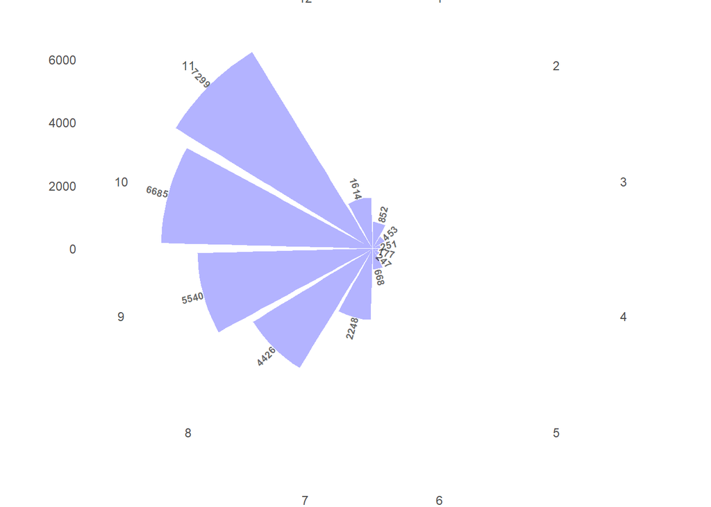

```r
suaci_hora_am <- suaci_21_24 %>%
  filter(prestacion == "vehículo mal estacionado"&
          grepl("am", hora_ingreso) ) %>%
  mutate(hora_ingreso = strptime(hora_ingreso, format = "%H:%M:%S"))


suaci_hora <- suaci_hora_am %>%
  mutate(hora = hour(hora_ingreso)) %>%
  group_by(hora) %>%
  count()

label_data <- suaci_hora

number_of_bar <- nrow(label_data)
angle <-  90 - 360 * (label_data$hora-0.5) /number_of_bar
label_data$hjust<-ifelse( angle < -90, 1, 0)

label_data$angle<-ifelse(angle < -90, angle+180, angle)

p <- ggplot(suaci_hora, aes(x=as.factor(hora), y=n)) +
  geom_bar(stat="identity", fill=alpha("blue", 0.3)) +
  coord_polar() +
    geom_text(data=label_data, aes(x=hora, y=n+10, label=n, hjust=hjust), color="black", fontface="bold",alpha=0.6, size=2.5, angle= label_data$angle, inherit.aes = FALSE ) +
    theme_minimal() +
  theme(
    axis.title = element_blank(),
    panel.grid = element_blank(),
    plot.margin = unit(rep(-1,4), "cm")
  )

p
```

Mapas para visualizar la cantidad de denuncias por comuna

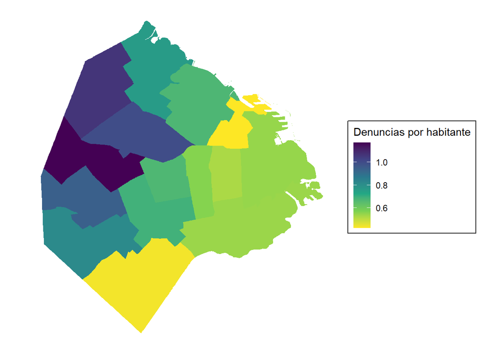

```r
mapa_denuncias_total <- ggplot() +
  geom_sf(data = denuncias_poblacion$geometry,
          aes(fill = denuncias_poblacion$n), color = NA)+
  scale_fill_viridis_c("Denuncias totales", direction = -1) +
  theme(legend.position = "right",
        panel.background = element_rect(fill='transparent'),
        plot.background = element_rect(fill='transparent', color=NA),
        panel.grid.major = element_blank(),
        panel.grid.minor = element_blank(),
        legend.background = element_rect(fill='transparent'),
        legend.box.background = element_rect(fill='transparent'),
        axis.text = element_blank(),
        axis.ticks = element_blank())

mapa_denuncias_ratio <- ggplot() +
  geom_sf(data = denuncias_poblacion$geometry,
          aes(fill = denuncias_poblacion$ratio), color = NA)+
  scale_fill_viridis_c("Denuncias por habitante", direction = -1)  +
  theme(legend.position = "right",
        panel.background = element_rect(fill='transparent'),
        plot.background = element_rect(fill='transparent', color=NA),
        panel.grid.major = element_blank(),
        panel.grid.minor = element_blank(),
        legend.background = element_rect(fill='transparent'),
        legend.box.background = element_rect(fill='transparent'),
        axis.text = element_blank(),
        axis.ticks = element_blank())

mapa_denuncias_ratio
```

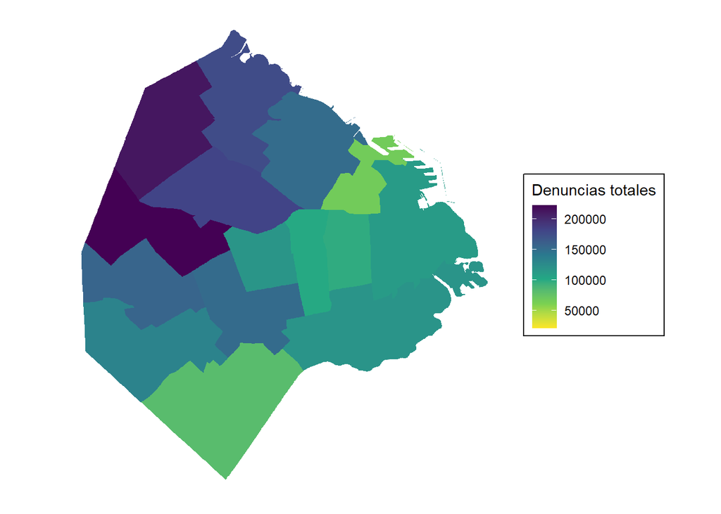

```r
mapa_denuncias_total
```